# Predicting tumor subgroup in pseudobulk and single cells

Steven Foltz

2023

This notebook uses a medulloblastoma subgroup prediction model to predict the subgroup of pseudobulk samples and individual cells from single-cell RNA-seq experiments. Pseudobulk samples are generated from single-cell experiments by averaging gene expression across all cells on a per gene level. Prediction models were trained using bulk gene expression data (bulk array and RNA-seq) in `analysis_notebooks/baseline_models.Rmd`. Here, we use the trained kTSP model to predict single cell subgroups from scRNA-seq data generated by [Hovestadt, et. al](https://www.nature.com/articles/s41586-019-1434-6).

# Setup

```r
set.seed(8222)

# Load libraries
source(here::here("utils/color_schemes.R"))
source(here::here("utils/modeling.R"))
source(here::here("utils/single-cell.R"))
library(patchwork)

# Directories
models_dir <- here::here("models")
plots_dir <- here::here("plots")
plots_data_dir <- file.path(plots_dir, "data")
processed_data_dir <- here::here("processed_data")
pseudobulk_sce_dir <- file.path(processed_data_dir, "pseudobulk_sce")

# Input files
pseudobulk_genex_filepath <- file.path(processed_data_dir, "pseudobulk_genex.tsv")
pseudobulk_metadata_filepath <- file.path(processed_data_dir, "pseudobulk_metadata.tsv")

# baseline models are generated prior to this in the notebook analysis_notebooks/baseline_models.Rmd
# there is one baseline model designated as the official model that is used to test single cells here
# "baseline" means that we used all genes and all available training/test data in modeling
baseline_models_filepath <- file.path(models_dir, "baseline.rds")

# Output files
single_cell_plot_data_filepath <- file.path(plots_data_dir, "single_cell_test_predictions.tsv")
pseudobulk_plot_data_filepath <- file.path(plots_data_dir, "pseudobulk_test_predictions.tsv")
pseudobulk_subgroups_plot_filepath <- file.path(plots_dir, "single_cell_pseudobulk_subgroups.pdf")
percentage_subgroups_plot_filepath <- file.path(plots_dir, "single_cell_percentage_subgroups.pdf")
confidence_umap_plot_filepath <- file.path(plots_dir, "single_cell_confidence_umap.pdf")
cluster_umap_plot_filepath <- file.path(plots_dir, "single_cell_cluster_umap.pdf")
combined_percentage_plot_filepath <- file.path(plots_dir, "single_cell_combined_percentage.pdf")
combined_umap_plot_filepath <- file.path(plots_dir, "single_cell_combined_umap.pdf")

# Read in data
pseudobulk_genex_df <- readr::read_tsv(pseudobulk_genex_filepath,
                                       show_col_types = FALSE) |>
  tibble::column_to_rownames(var = "gene")
pseudobulk_metadata_df <- readr::read_tsv(pseudobulk_metadata_filepath,
                                          show_col_types = FALSE) |>
  dplyr::mutate(sample_accession = title)

baseline_models <- readr::read_rds(baseline_models_filepath)
official_model <- which(purrr::map_lgl(baseline_models, \(x) x[["official_model"]]))

classifier_list <- list(ktsp = baseline_models[[official_model]]$ktsp_weighted$classifier,
                        rf = baseline_models[[official_model]]$rf_weighted$classifier)

model_types <- c("ktsp", "rf")
mb_subgroups <- c("G3", "G4", "SHH", "WNT")
```

# Predict the subgroup of pseudobulk samples

```r
pseudobulk_test_list <- list("ktsp" = test_ktsp(genex_df_test = pseudobulk_genex_df,
                                                metadata_df_test = pseudobulk_metadata_df,
                                                classifier = classifier_list[["ktsp"]],
                                                labels = mb_subgroups),
                             "rf" = test_rf(genex_df_test = pseudobulk_genex_df,
                                            metadata_df_test = pseudobulk_metadata_df,
                                            classifier = classifier_list[["rf"]]))
```

# Plot pseudobulk subgroup predictions

### Prep plotting data

```r
pseudobulk_plot_df <- purrr::map(model_types,
                                 \(model_type) pseudobulk_test_list[[model_type]]$model_output |>
                                   as.data.frame() |>
                                   tibble::rownames_to_column(var = "sample_accession") |>
                                   tibble::as_tibble() |>
                                   tidyr::pivot_longer(cols = all_of(mb_subgroups),
                                                       names_to = "predicted_subgroup") |>
                                   dplyr::select(sample_accession,
                                                 predicted_subgroup,
                                                 value) |>
                                   dplyr::mutate(model_type = model_type)) |>
  dplyr::bind_rows() |>
  dplyr::left_join(pseudobulk_metadata_df |>
              dplyr::select(sample_accession,
                            subgroup),
              by = "sample_accession") |>
  dplyr::mutate(model_type = dplyr::case_match(model_type,
                                               "ktsp" ~ "kTSP (w)",
                                               "rf" ~ "RF (w)"))

readr::write_tsv(x = pseudobulk_plot_df,
                 file = pseudobulk_plot_data_filepath)
```

# Plot pseudobulk subgroup predictions

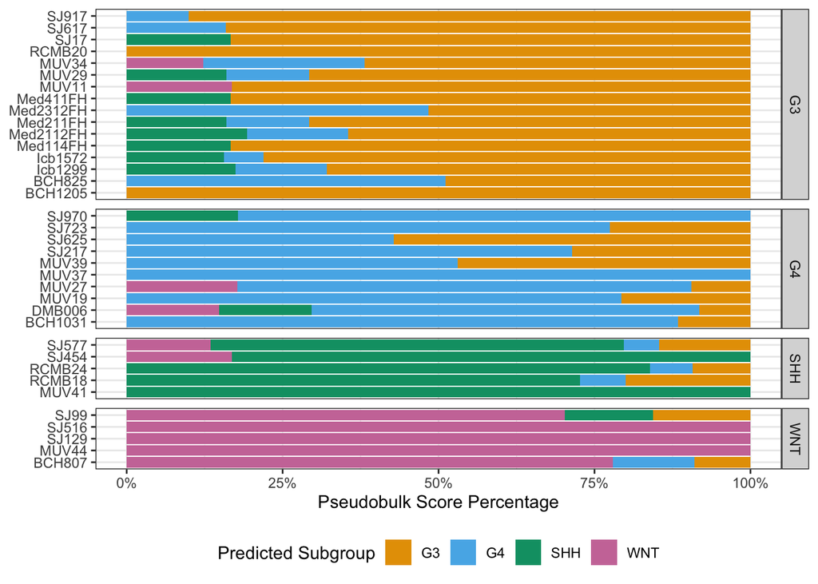

```r
pseudobulk_subgroups_plot_object <- pseudobulk_plot_df |>
  dplyr::filter(model_type == "kTSP (w)") |>
  ggplot2::ggplot(ggplot2::aes(y = sample_accession,
                               x = value,
                               fill = predicted_subgroup)) +
  ggplot2::geom_col(position = "fill") +
  ggplot2::scale_x_continuous(labels = scales::percent) +
  ggplot2::facet_grid(rows = ggplot2::vars(subgroup),
                      space = "free_y",
                      scales = "free_y") +
  ggplot2::scale_fill_manual(values = subgroup_colors) +
  ggplot2::labs(x = "Pseudobulk Score Percentage",
                y = NULL,
                fill = "Predicted Subgroup") +
  ggplot2::theme_bw() +
  ggplot2::theme(legend.position = "bottom",
                 legend.direction = "horizontal")

ggplot2::ggsave(filename = pseudobulk_subgroups_plot_filepath,
                plot = pseudobulk_subgroups_plot_object,
                width = 7.5,
                height = 6)

pseudobulk_subgroups_plot_object
```

# Predict the subgroup of single cells

```r
model_test_list <- purrr::map(model_types,
                              \(model_type) purrr::map(pseudobulk_metadata_df$title,
                                                       \(x) test_single_cells(sample_acc = x,
                                                                              sce_filepath = file.path(pseudobulk_sce_dir,
                                                                                                       stringr::str_c(x, "_sce.rds")),
                                                                              metadata_df = pseudobulk_metadata_df,
                                                                              labels = mb_subgroups,
                                                                              classifier = classifier_list[[model_type]],
                                                                              model_type = model_type,
                                                                              study = "GSE119926",
                                                                              platform = "scRNA-seq")) |>
                                purrr::set_names(pseudobulk_metadata_df$title)) |>
  purrr::set_names(model_types)
```

# Plot single cell subgroup predictions

### Prep plotting data

```r
return_umap_cluster <- function(sample_title) {

  sce_filepath <- file.path(pseudobulk_sce_dir,
                            stringr::str_c(sample_title, "_sce.rds"))

  sce_object <- readr::read_rds(sce_filepath)

  umap_df <- data.frame(sample = sample_title,
                        SingleCellExperiment::reducedDim(sce_object, "UMAP"),
                        cluster = SummarizedExperiment::colData(sce_object)$louvain_10) |>
    dplyr::mutate(cell_index = dplyr::row_number())

  names(umap_df) <- c("sample_accession", "UMAP_1", "UMAP_2", "cluster", "cell_index")
  row.names(umap_df) <- NULL

  return(umap_df)

}

umap_list <- purrr::map(pseudobulk_metadata_df$title,
                        \(sample_title) return_umap_cluster(sample_title)) |>
  dplyr::bind_rows()

single_cell_plot_df <- purrr::map(model_types,
                                  \(model_type) purrr::map(model_test_list[[model_type]],
                                                           \(x) dplyr::bind_cols(x$predicted_labels_df,
                                                                                 tibble::as_tibble(x$model_output)) |>
                                                             tidyr::separate_wider_delim(cols = sample_accession,
                                                                                         delim = "_",
                                                                                         names = c("sample_accession",
                                                                                                   "cell_index"))) |>
                                    dplyr::bind_rows()) |>
  purrr::set_names(model_types) |>
  dplyr::bind_rows(.id = "model_type") |>
  dplyr::rowwise() |>
  dplyr::mutate(max = max(G3, G4, SHH, WNT),
                total = sum(G3, G4, SHH, WNT),
                confidence = max/total,
                cell_index = as.numeric(cell_index)) |>
  dplyr::ungroup() |>
  dplyr::left_join(umap_list,
                   by = c("sample_accession", "cell_index")) |>
  dplyr::left_join(pseudobulk_metadata_df |>
                     dplyr::select(sample_accession,
                                   study,
                                   subgroup,
                                   is_PDX),
                   by = "sample_accession")

readr::write_tsv(x = single_cell_plot_df,
                 file = single_cell_plot_data_filepath)
```

### Plot percentage of subgroups

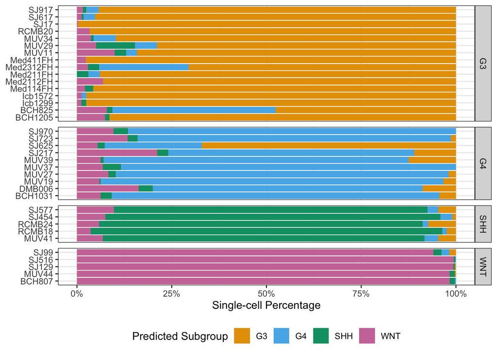

```r
percentage_subgroups_plot_object <- single_cell_plot_df |>
  dplyr::filter(model_type == "ktsp") |>
  dplyr::count(sample_accession, subgroup, predicted_labels) |>
  ggplot2::ggplot(ggplot2::aes(y = sample_accession,
                               x = n,
                               fill = predicted_labels)) +
  ggplot2::geom_col(position = ggplot2::position_fill()) +
  ggplot2::scale_x_continuous(labels = scales::percent) +
  ggplot2::facet_grid(rows = ggplot2::vars(subgroup),
                      space = "free_y",
                      scales = "free_y") +
  ggplot2::scale_fill_manual(values = subgroup_colors) +
  ggplot2::labs(y = NULL,
                x = "Single-cell Percentage",
                fill = "Predicted Subgroup") +
  ggplot2::theme_bw() +
  ggplot2::theme(legend.position = "bottom")

ggplot2::ggsave(filename = percentage_subgroups_plot_filepath,
                plot = percentage_subgroups_plot_object,
                height = 10,
                width = 7.5)

percentage_subgroups_plot_object
```

- Most samples show the same tumor subgroup predicted for most of their cells
- Three samples (“BCH825”, “Med2312FH”, “SJ625”) show a mixture of predicted subgroups (G3/G4)

# Plot confidence of subgroup predictions

### Prep plotting data

```r
mixed_samples <- sort(c("BCH825", "Med2312FH", "SJ625"))

mixed_samples_with_subgroup <- pseudobulk_metadata_df |>
  dplyr::filter(sample_accession %in% mixed_samples) |>
  dplyr::mutate(sample_with_subgroup = stringr::str_c(title, " (", subgroup, ")")) |>
  dplyr::select(sample_accession, subgroup, sample_with_subgroup)
```

### Plot UMAPs with subgroup prediction

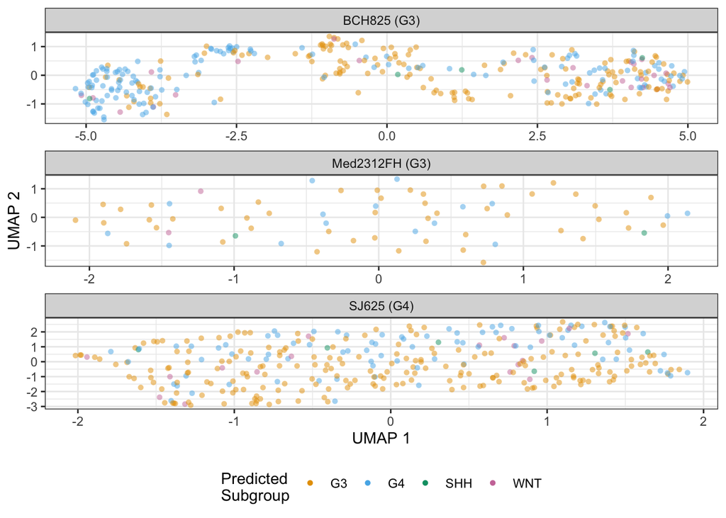

```r
confidence_umap_plot_object <- single_cell_plot_df |>
  dplyr::filter(model_type == "ktsp",
                sample_accession %in% mixed_samples) |>
  dplyr::left_join(mixed_samples_with_subgroup,
                   by = "sample_accession") |>
  ggplot2::ggplot(ggplot2::aes(x = UMAP_1,
                               y = UMAP_2,
                               color = predicted_labels)) +
  ggplot2::geom_point(shape = 16,
                      alpha = 0.5) +
  ggplot2::scale_color_manual(values = subgroup_colors) +
  ggplot2::scale_alpha_continuous(range = c(0, 1)) +
  ggplot2::facet_wrap(~ sample_with_subgroup,
                      ncol = 1,
                      scales = "free") +
  ggplot2::labs(x = "UMAP 1",
                y = "UMAP 2",
                color = "Predicted\nSubgroup") +
  ggplot2::guides(colour = ggplot2::guide_legend(override.aes = list(alpha = 1))) +
  ggplot2::theme_bw() +
  ggplot2::theme(legend.position = "bottom",
                 legend.direction = "horizontal")

ggplot2::ggsave(filename = confidence_umap_plot_filepath,
                plot = confidence_umap_plot_object,
                width = 7.5,
                height = 6)

confidence_umap_plot_object
```

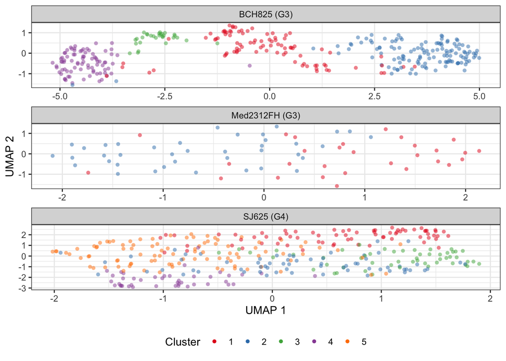

```r
cluster_umap_plot_object <- single_cell_plot_df |>
  dplyr::filter(model_type == "ktsp",
                sample_accession %in% mixed_samples) |>
  dplyr::left_join(mixed_samples_with_subgroup,
                   by = "sample_accession") |>
  ggplot2::ggplot(ggplot2::aes(x = UMAP_1,
                               y = UMAP_2,
                               color = cluster)) +
  ggplot2::geom_point(shape = 16,
                      alpha = 0.5) +
  ggplot2::facet_wrap(~ sample_with_subgroup,
                      ncol = 1,
                      scales = "free") +
  ggplot2::scale_color_brewer(palette = "Set1") +
  ggplot2::labs(x = "UMAP 1",
                y = "UMAP 2",
                color = "Cluster") +
  ggplot2::guides(colour = ggplot2::guide_legend(override.aes = list(alpha = 1))) +
  ggplot2::theme_bw() +
  ggplot2::theme(legend.position = "bottom",
                 legend.direction = "horizontal")

ggplot2::ggsave(filename = cluster_umap_plot_filepath,
                plot = cluster_umap_plot_object,
                width = 7.5,
                height = 6)

cluster_umap_plot_object
```

### Plot confidence of individual cell predictions

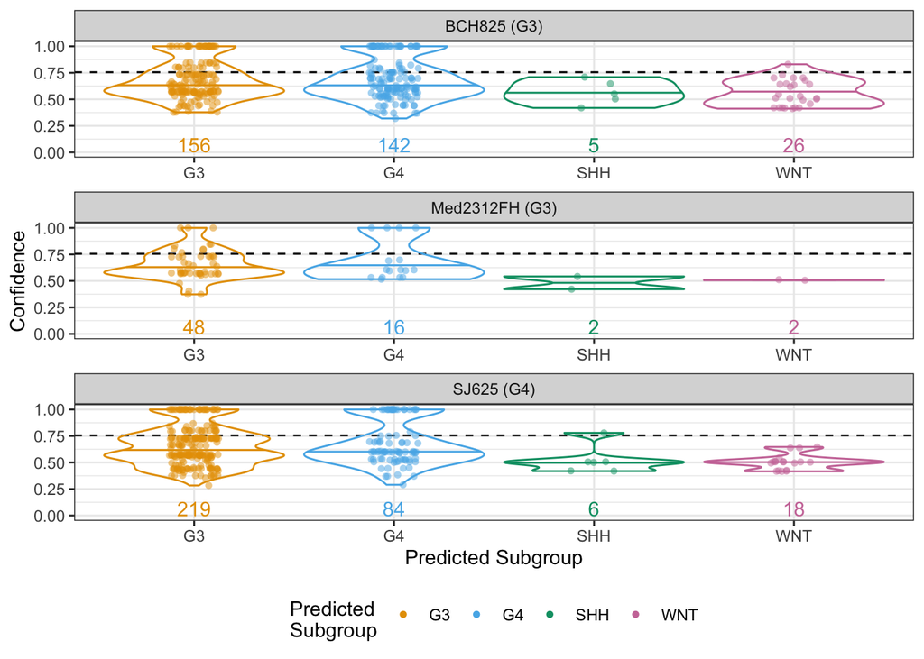

```r
typical_confidence <- single_cell_plot_df |>
  dplyr::filter(model_type == "ktsp",
                !is.na(confidence)) |>
  dplyr::group_by(sample_accession,
                  subgroup,
                  predicted_labels) |>
  dplyr::summarize(median_confidence = median(confidence),
                   .groups = "drop") |>
  tidyr::pivot_wider(names_from = predicted_labels,
                     values_from = median_confidence) |>
  dplyr::rowwise() |>
  dplyr::mutate(subgroup_conf = c(G3, G4, SHH, WNT)[which(mb_subgroups == subgroup)]) |>
  dplyr::pull(subgroup_conf) |>
  median()

cell_counts_df <- single_cell_plot_df |>
  dplyr::filter(model_type == "ktsp",
                sample_accession %in% mixed_samples,
                !is.na(confidence)) |>
  dplyr::left_join(mixed_samples_with_subgroup,
                   by = "sample_accession") |>
  dplyr::count(sample_with_subgroup,
               predicted_labels)

confidence_plot_object <- single_cell_plot_df |>
  dplyr::filter(model_type == "ktsp",
                sample_accession %in% mixed_samples,
                !is.na(confidence)) |>
  dplyr::left_join(mixed_samples_with_subgroup,
                   by = "sample_accession") |>
  ggplot2::ggplot(ggplot2::aes(x = predicted_labels,
                               y = confidence,
                               color = predicted_labels)) +
  ggplot2::geom_hline(yintercept = typical_confidence,
                      lty = 2) +
  ggplot2::geom_violin(fill = NA,
                       draw_quantiles = 0.5,
                       position = ggplot2::position_dodge(width = 0.75), scale = "width",
                       show.legend = FALSE) +
  ggplot2::geom_point(shape = 16,
                      alpha = 0.5,
                      position = ggplot2::position_jitterdodge(jitter.height = 0,
                                                               jitter.width = 0.25)) +
  ggplot2::geom_text(data = cell_counts_df,
                     ggplot2::aes(label = n),
                     y = 0,
                     vjust = 0,
                     show.legend = FALSE) +
  ggplot2::facet_wrap(~ sample_with_subgroup,
                      ncol = 1,
                      scales = "free") +
  ggplot2::scale_color_manual(values = subgroup_colors) +
  ggplot2::scale_y_continuous(limits = c(0, NA)) +
  ggplot2::labs(x = "Predicted Subgroup",
                y = "Confidence",
                color = "Predicted\nSubgroup") +
  ggplot2::guides(colour = ggplot2::guide_legend(override.aes = list(alpha = 1))) +
  ggplot2::theme_bw() +
  ggplot2::theme(legend.position = "bottom",
                 legend.direction = "horizontal")

ggplot2::ggsave(filename = confidence_umap_plot_filepath,
                plot = confidence_plot_object,
                width = 7.5, height = 6)

confidence_plot_object
```

- Cell subgroup predictions are more confident when subgroup predictions are consistent across entire sample.
- The relative confidence levels of each cell’s prediction show that predictions in samples with one dominant subgroup are more confident than in samples with mixed subgroup predictions (BCH825, Med2312FH, SJ625).
- While some cells from mixed subgroup samples show high confidence as G3 or G4, most show that cells receive signals from both G3 and G4 rules, meaning they have an intermediate phenotype, rather than being a mixture of true G3 and true G4 cells.

### G3 and G4 prediction confidence exists on a G3-G4 spectrum

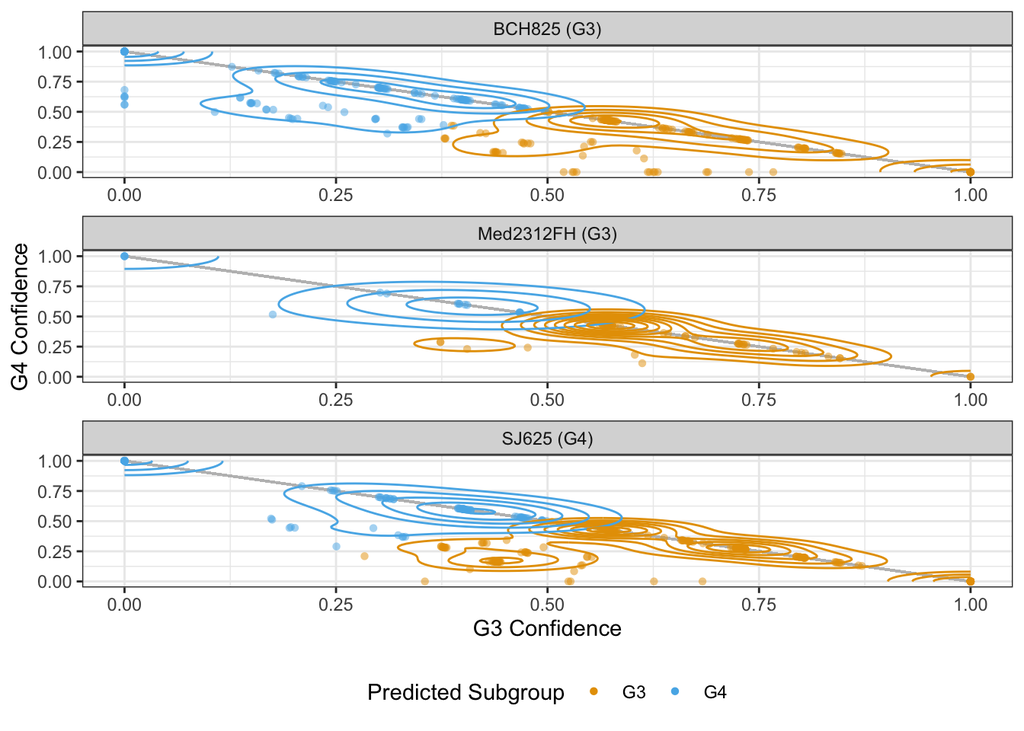

```r
joint_G3_G4_df <- single_cell_plot_df |>
  dplyr::filter(model_type == "ktsp",
                sample_accession %in% mixed_samples,
                !is.na(confidence)) |>
  dplyr::left_join(mixed_samples_with_subgroup,
                   by = "sample_accession") |>
  dplyr::filter(predicted_labels %in% c("G3", "G4"))

# what percentage of cells have no contribution from SHH or WNT (G3 and G4 only)
diagonal_pct <- mean(joint_G3_G4_df$SHH == 0 & joint_G3_G4_df$WNT == 0)*100

joint_G3_G4_confidence_plot_object <- joint_G3_G4_df |>
  ggplot2::ggplot(ggplot2::aes(x = G3/total,
                               y = G4/total,
                               color = predicted_labels)) +
  ggplot2::geom_segment(x = 0, xend = 1,
                        y = 1, yend = 0,
                        color = "grey",
                        lty = 1) +
  ggplot2::geom_point(shape = 16,
                      alpha = 0.5) +
  ggplot2::geom_density_2d(show.legend = FALSE) +
  ggplot2::facet_wrap(~ sample_with_subgroup,
                      ncol = 1,
                      scales = "free") +
  ggplot2::scale_color_manual(values = subgroup_colors) +
  ggplot2::labs(x = "G3 Confidence",
                y = "G4 Confidence",
                color = "Predicted Subgroup") +
  ggplot2::guides(colour = ggplot2::guide_legend(override.aes = list(alpha = 1))) +
  ggplot2::theme_bw() +
  ggplot2::theme(legend.position = "bottom",
                 legend.direction = "horizontal")

joint_G3_G4_confidence_plot_object
```

- Prediction confidence of G3 and G4 cells forms a spectrum between poles at 100% G3 and 100% G4.
- Some cells have some score contributed from other subgroups, but most (77.4%) are on the diagonal.

# Combined plots

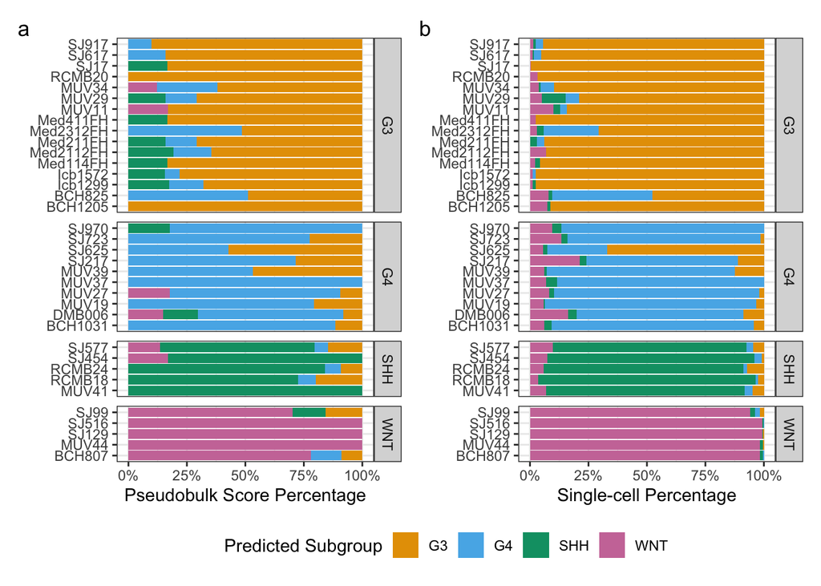

```r
combined_percentage_plot_object <- pseudobulk_subgroups_plot_object + percentage_subgroups_plot_object +
  patchwork::plot_layout(guides = "collect") +
  patchwork::plot_annotation(tag_levels = 'a') &
  ggplot2::theme(legend.position = "bottom")

ggplot2::ggsave(filename = combined_percentage_plot_filepath,
                plot = combined_percentage_plot_object,
                width = 7.5,
                height = 6)

combined_percentage_plot_object
```

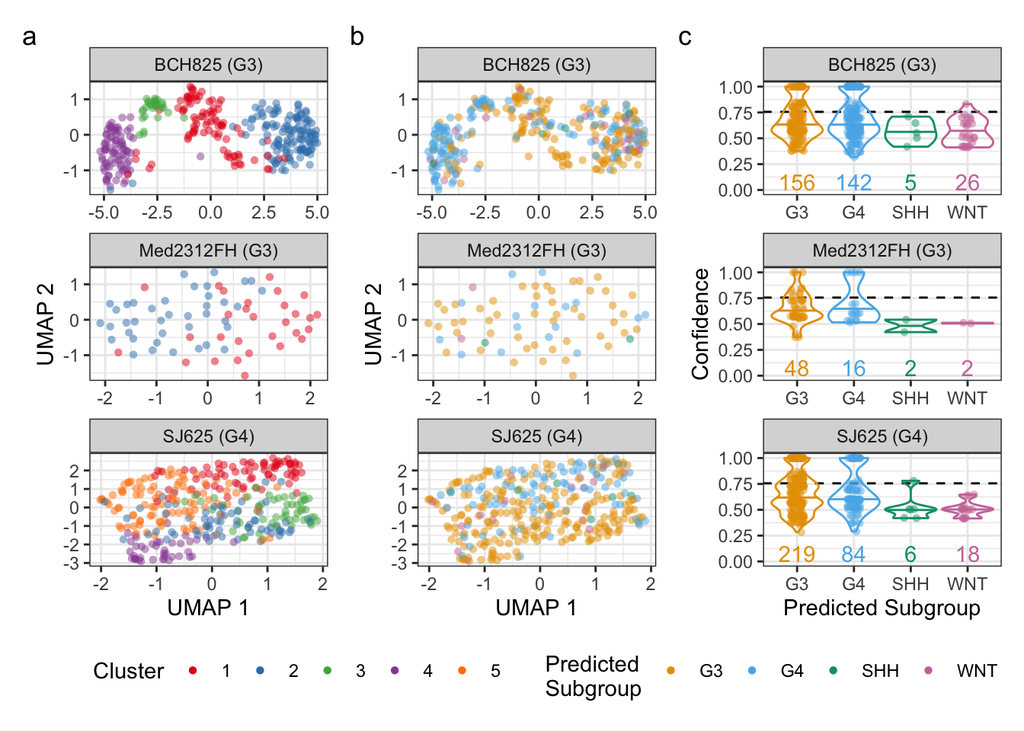

```r
combined_umap_plot_object <- cluster_umap_plot_object + confidence_umap_plot_object + confidence_plot_object +
  patchwork::plot_annotation(tag_levels = 'a') +
  patchwork::plot_layout(guides = "collect") &
  ggplot2::theme(legend.position = "bottom")

ggplot2::ggsave(filename = combined_umap_plot_filepath,
                plot = combined_umap_plot_object,
                width = 7.5,
                height = 6)

combined_umap_plot_object
```